# Text mining and sentiment analysis of a Stuff You Should Know Podcast

Dr. Shirin Glander

2016-11-03

# Text mining and sentiment analysis of a Stuff You Should Know Podcast

For many years now, I’ve been listening to [Josh](http://www.stuffyoushouldknow.com/about-josh.htm) and [Chuck](http://www.stuffyoushouldknow.com/about-chuck.htm) teach me “stuff I should know”. I’ve learned so many things I’ve never thought much about before! Today I want to use one of their podcasts to learn a little bit about text analysis in R.

Inititally, I wanted to explore all SYSK podcasts. Unfortunately however, I could only find a transcript for the episode [Earwax: Live With It](http://www.stuffyoushouldknow.com/podcasts/earwax-live-with-it-2.htm), posted on March 19, 2015.

## Loading the transcript

The episode transcript can be [downloaded from Github](https://github.com/ShirinG/blog_posts_prep/blob/master/sysk/sysk_earwax.transcript.txt).

```r
# read Lines of transcript
raw <- readLines("sysk_earwax.transcript.txt")
head(raw)
```

```
## [1] "Josh: Hey, and welcome to the podcast. I'm Josh Clark. There is Charles W. \"Chuck\" Bryant, there is Jeri. Yeah, it's Stuff You Should Know."
## [2] ""
## [3] "Chuck: He just shrugged."
## [4] ""
## [5] "Josh: Yeah, like \"eh, what are we going to do? That's what we are.\""
## [6] ""
```

## Separating Josh and Chuck

Of course, I wouldn’t actually want to separate Josh and Chuck. But for comparison’s sake, I will create two separate files for dialogue spoken by Josh and Chuck.

I am also keeping the combined data for background information.

```r
names <- c("Josh", "Chuck")

for (name in names){
  # grep lines from Josh or Chuck
  assign(paste("lines", name, sep = "_"), as.character(raw[grep(paste0("^", name, ":"), raw)]))
}
```

```r
# and removing the beginning of each line telling me who's speaking
lines_Josh <- gsub("^Josh: ", "", lines_Josh)
lines_Chuck <- gsub("^Chuck: ", "", lines_Chuck)

lines_bg <- c(lines_Josh, lines_Chuck)
```

## Building a corpus

In text analysis, a corpus refers to a collection of documents. Here, I am using the [tm](https://cran.r-project.org/web/packages/tm/index.html) package to create by corpus from the character vectors of Josh’s and Chuck’s lines. [SnowballC](https://cran.r-project.org/web/packages/SnowballC/index.html) is used for its word stemming algorithm.

Before I can analyse the text data meaningfully, I have to do some pre-processing:

1. Removing punctuation

   Here, I am removing all punctuation marks. Before I do that, I will transform all hypens to a space, because the text includes some words which are connected by hyphens and would otherwise be connected if I simply removed the hyphen with the removePunctuation function.
2. Transforming to lower case

   R character string processing is case-sensitive, so everything will be converted to lower case
3. Stripping numbers

   Numbers are usually not very meaningful for text analysis (if we are not specifically interested in dates, for example), so they are removed as well.
4. Removing stopwords

   Stopwords are collections of very common words which by themselves don’t tell us very much about the content of a text (e.g. and, but, the, however, etc.). The tm packages includes a list of stopwords for the English language.
5. Stripping whitespace

   I’m also removing all superfluous whitespace around words.
6. Stemming

   Finally, I’m stemming the words in the corpus. This means that words with a common root are shortened to this root. Even though stemming algorithms are not perfect, they allow us to compare conjugated words from the same origin.

```r
library(tm)
data("crude")
library(SnowballC)

transform_to_space <- content_transformer(function(x, pattern) gsub(pattern, " ", x))

names <- c("Josh", "Chuck", "bg")

for (name in names){
  corpus <- Corpus(VectorSource(get(paste("lines", name, sep = "_"))))

  # Removing punctuation
  corpus <- tm_map(corpus, transform_to_space, "-")
  corpus <- tm_map(corpus, removePunctuation)

  # Transforming to lower case
  corpus <- tm_map(corpus, content_transformer(tolower))

  # Stripping numbers
  corpus <- tm_map(corpus, removeNumbers)

  # Removing stopwords
  corpus <- tm_map(corpus, removeWords, stopwords("english"))

  # Stripping whitespace
  corpus <- tm_map(corpus, stripWhitespace)

  # Stemming
  corpus <- tm_map(corpus, stemDocument)

  # Converting said to say because this isn't included in stemDocument
  corpus <- tm_map(corpus, gsub, pattern = "said", replacement = "say")

  # There are a couple of words not included among the stopwords that I would like to remove
  myStopwords <- c("one", "two", "three", "just", "your", "that", "can")
  corpus <- tm_map(corpus, removeWords, myStopwords)

  # Assigning to object and treat as text document
  assign(paste("corpus", name, sep = "_"), tm_map(corpus, PlainTextDocument))
}

corpus_Josh
```

```
## <<VCorpus>>
## Metadata:  corpus specific: 0, document level (indexed): 0
## Content:  documents: 227
```

```r
corpus_Chuck
```

```
## <<VCorpus>>
## Metadata:  corpus specific: 0, document level (indexed): 0
## Content:  documents: 226
```

```r
corpus_bg
```

```
## <<VCorpus>>
## Metadata:  corpus specific: 0, document level (indexed): 0
## Content:  documents: 453
```

## Creating the Document Term Matrix

The document term matrix (DTM) lists the number of occurrences of each word per document in the corpus. Here, each *document* in the corpus represents one line of dialogue from the original transcript.

By restricting the DTM to words to words with at least 3 letters and an occurence in at least 3 lines of dialogue, we can exclude less specific terms.

```r
for (name in names){
  assign(paste("dtm", name, sep = "_"), DocumentTermMatrix(get(paste("corpus", name, sep = "_")),
         control = list(wordLengths = c(3, 100), bounds = list(global = c(3, length(get(paste("lines", name, sep = "_"))))))))
}

dtm_Josh
```

```
## <<DocumentTermMatrix (documents: 227, terms: 126)>>
## Non-/sparse entries: 801/27801
## Sparsity           : 97%
## Maximal term length: 10
## Weighting          : term frequency (tf)
```

```r
dtm_Chuck
```

```
## <<DocumentTermMatrix (documents: 226, terms: 122)>>
## Non-/sparse entries: 779/26793
## Sparsity           : 97%
## Maximal term length: 10
## Weighting          : term frequency (tf)
```

```r
dtm_bg
```

```
## <<DocumentTermMatrix (documents: 453, terms: 260)>>
## Non-/sparse entries: 1945/115835
## Sparsity           : 98%
## Maximal term length: 10
## Weighting          : term frequency (tf)
```

As the term *Sparsity* tell us that 97% of the DTM are zeros.

### Word frequencies

By summing up the occurences of each word over all documents we get the word count frequencies.

```r
for (name in names){
  assign(paste("freq_dtm", name, sep = "_"), colSums(as.matrix(get(paste("dtm", name, sep = "_")))))
}
```

```r
for (name in names){
  print(findFreqTerms(get(paste("dtm", name, sep = "_")), lowfreq=40))
  print(findAssocs(get(paste("dtm", name, sep = "_")), "ear", 0.4))
}
```

```
## [1] "ear"    "earwax" "yeah"
## $ear
## canal candl
##  0.44  0.44
##
## [1] "ear"  "yeah"
## $ear
## canal  want clean
##  0.54  0.44  0.42
##
## [1] "dont"   "ear"    "earwax" "like"   "right"  "say"    "think"  "yeah"
## $ear
## canal candl
##  0.49  0.42
```

```r
length(freq_dtm_Josh)
```

```
## [1] 126
```

```r
length(freq_dtm_Chuck)
```

```
## [1] 122
```

```r
length(freq_dtm_bg)
```

```
## [1] 260
```

The most frequent words with a count bigger than 40 include (not surprisingly) *“ear”* and *“earwax”*, but funnily also *“yeah”*.

The terms most strongly correlated (40%) with *“ear”* (*“canal”*, *“candl”*, *“clean”*, *“want”*) already give us an idea about the most discussed aspects in the podcast.

Josh and Chuck spoke roughly the same number of words, so good job on not dominating the discussion. ;-)

#### Word association heatmaps

The associations of words with an association bigger than 60% were plotted in a heatmap to find words that most often co-occured.

```r
library(dplyr)

for (name in names){

  for (i in 1:length(names(get(paste("freq_dtm", name, sep = "_"))))){
      associations <- as.data.frame(findAssocs(get(paste("dtm", name, sep = "_")), names(get(paste("freq_dtm", name, sep = "_")))[i], 0))
      associations$word <- rownames(associations)

  if (i == 1){
    associations_table <- associations[, c(2, 1)]
  } else {
    associations_table <- full_join(associations_table, associations, by = "word")
  }

  if (i == length(names(get(paste("freq_dtm", name, sep = "_"))))){
    associations_table[is.na(associations_table)] <- 0
    assign(paste("associations_table", name, sep = "_"), associations_table)
  }
  }
}
```

```r
# setting my custom theme of choice
library(ggplot2)

my_theme <- function(base_size = 12, base_family = "sans"){
  theme_grey(base_size = base_size, base_family = base_family) +
  theme(
    axis.text = element_text(size = 12),
    axis.text.x = element_text(angle = 45, hjust = 1, vjust = 1),
    axis.title = element_text(size = 14),
    panel.grid.major = element_line(colour = "grey"),
    panel.grid.minor = element_blank(),
    panel.background = element_rect(fill = "aliceblue"),
    strip.background = element_rect(fill = "lightgrey", color = "grey", size = 1),
    strip.text = element_text(face = "bold", size = 12, colour = "navy"),
    legend.position = "bottom",
    panel.margin = unit(.5, "lines"),
    panel.border = element_rect(color = "grey", fill = NA, size = 0.5)
  )
}
```

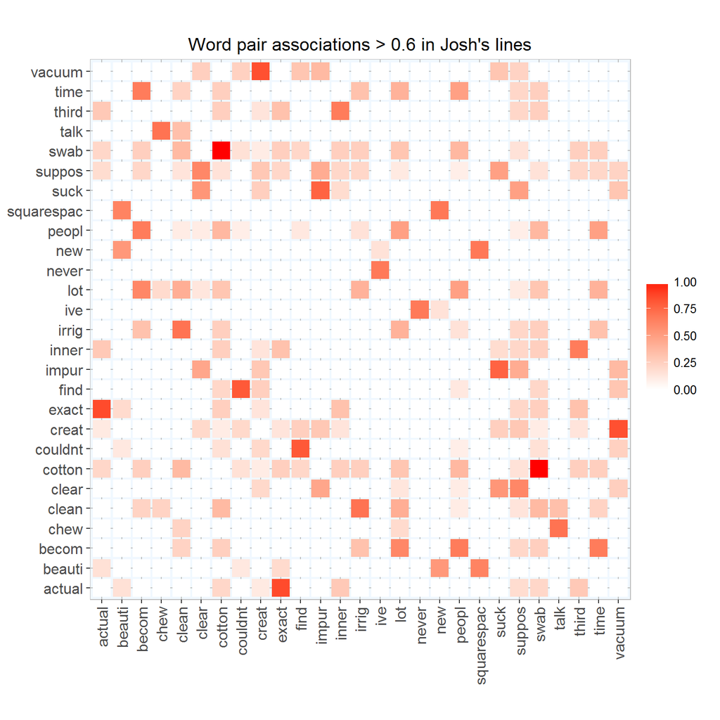

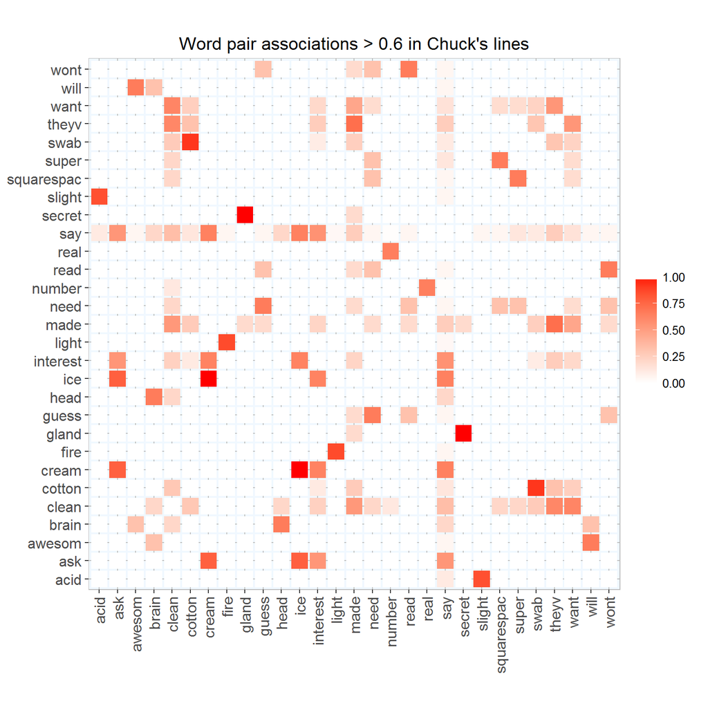

[figure not shown]

```r
library(reshape2)

cor = 0.6

for (name in names){
  top_words <- get(paste("associations_table", name, sep = "_"))
  top_words <- top_words[apply(top_words[, -1], 1, function(x) any(x > cor)), c(TRUE, apply(top_words[, -1], 2, function(x) any(x > cor)))]

  associations_table_melt <- melt(top_words)

  p <- ggplot(data = associations_table_melt, aes(x = word, y = variable, fill = value)) +
    geom_tile(width=.9, height=.9) +
    scale_fill_gradient2(low = "white", high = "red",
                         limit = c(0,1), space = "Lab",
                         name="") +
    my_theme() +
    theme(
      axis.text.x = element_text(angle = 90, vjust = 0.5, hjust = 1),
      axis.title = element_blank(),
      legend.position = "right") +
    coord_fixed() +
    labs(title = paste0("Word pair associations > ", cor, " in ", name, "'s lines"))

  print(p)
}
```

Among the most conspicuous associations were cotton and swab in Josh’s lines (this was probably a hyphenated word to begin with: *cotton-swab*) and between secret and gland in Chuck’s line (secretory gland?).

#### Word count plots

```r
# create merged data frame for plotting
library(dplyr)

freq_df_Josh <- data.frame(words = names(freq_dtm_Josh), freq = freq_dtm_Josh)
freq_df_Chuck <- data.frame(words = names(freq_dtm_Chuck), freq = freq_dtm_Chuck)

freq_df <- full_join(freq_df_Josh, freq_df_Chuck, by = "words")

freq_df_bg  <- data.frame(words = names(freq_dtm_bg), freq = freq_dtm_bg)
freq_df <- full_join(freq_df, freq_df_bg, by = "words")

freq_df[is.na(freq_df)] <- 0
colnames(freq_df)[2:4] <- names

freq_df <- freq_df[apply(freq_df[, -1], 1, function(x) any(x > 10)), ]

# gather for plotting
library(tidyr)
freq_df_gather <- freq_df %>%
  gather(words, count)
colnames(freq_df_gather)[2] <- "name"
```

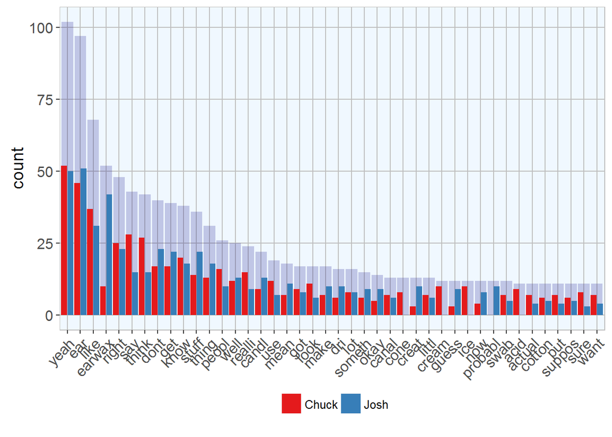

```r
# setting factor levels
f = as.factor(freq_df_bg[order(freq_df_bg$freq, decreasing = TRUE), "words"])
freq_df_gather <- within(freq_df_gather, words <- factor(words, levels = f))

ggplot(freq_df_gather, aes(x = words, y = count, fill = name)) +
  geom_bar(data = subset(freq_df_gather, name == "bg"), fill = "navy", alpha = .2, stat = "identity") +
  geom_bar(data = subset(freq_df_gather, name != "bg"), stat = "identity", position = position_dodge(width = 1)) +
  scale_fill_brewer(palette = "Set1", name = "") +
  my_theme() +
  theme(axis.title.x = element_blank())
```

### Wordcloud

[figure not shown]

```r
library(wordcloud)

#setting the same seed makes the look consisten
set.seed(42)

par(mfrow = c(1, 2))
wordcloud(names(freq_dtm_Josh), freq_dtm_Josh, min.freq = 5, colors = brewer.pal(6, "Dark2"))
wordcloud(names(freq_dtm_Chuck), freq_dtm_Chuck, min.freq = 5, colors = brewer.pal(6, "Dark2"))
```

### Quantitative analysis

```r
words <- dtm_Josh %>%
  as.matrix %>%
  colnames %>%
  (function(x) x[nchar(x) < 20])

length(words)
```

```
## [1] 126
```

```r
summary(nchar(words))
```

```
##    Min. 1st Qu.  Median    Mean 3rd Qu.    Max.
##    3.00    4.00    5.00    4.81    6.00   10.00
```

```r
table(nchar(words))
```

```
##
##  3  4  5  6  7  8  9 10
## 21 38 34 21  7  1  2  2
```

```r
library(qdap)
dist_tab(nchar(words))
```

```
##   interval freq cum.freq percent cum.percent
## 1        3   21       21   16.67       16.67
## 2        4   38       59   30.16       46.83
## 3        5   34       93   26.98       73.81
## 4        6   21      114   16.67       90.48
## 5        7    7      121    5.56       96.03
## 6        8    1      122    0.79       96.83
## 7        9    2      124    1.59       98.41
## 8       10    2      126    1.59      100.00
```

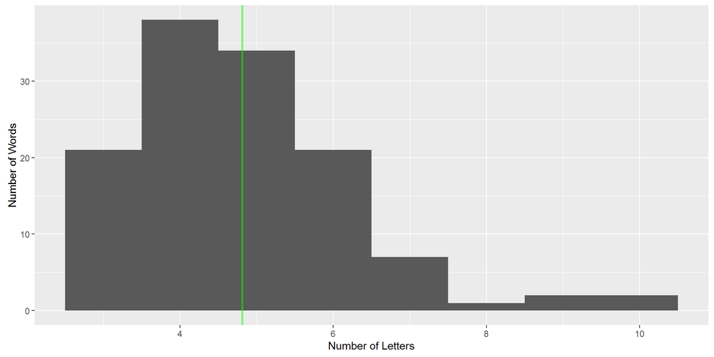

```r
# Word Length Counts
data.frame(nletters=nchar(words)) %>%
  ggplot(aes(x=nletters)) +
  geom_histogram(binwidth=1) +
  geom_vline(xintercept=mean(nchar(words)),
             colour="green", size=1, alpha=.5) +
  labs(x="Number of Letters", y="Number of Words")
```

### Letter Frequency

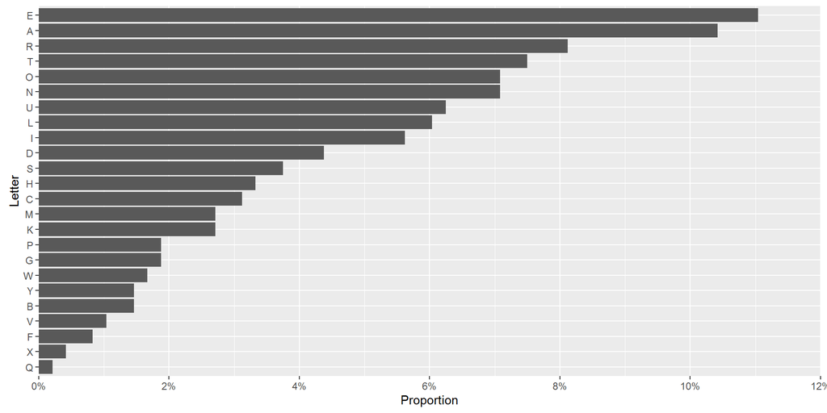

```r
library(stringr)

words %>%
  str_split("") %>%
  sapply(function(x) x[-1]) %>%
  unlist %>%
  dist_tab %>%
  mutate(Letter=factor(toupper(interval),
                       levels=toupper(interval[order(freq)]))) %>%
  ggplot(aes(Letter, weight=percent)) +
  geom_bar() +
  coord_flip() +
  labs(y="Proportion") +
  scale_y_continuous(breaks=seq(0, 12, 2),

                     label=function(x) paste0(x, "%"),expand=c(0,0), limits=c(0,12))
```

### Letter and Position Heatmap

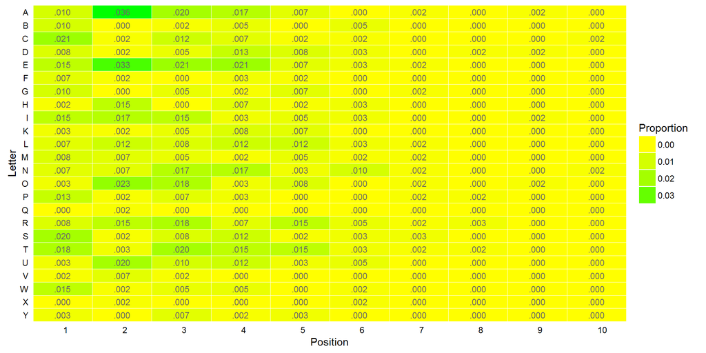

```r
words %>%
  lapply(function(x) sapply(letters, gregexpr, x, fixed=TRUE)) %>%
  unlist %>%
  (function(x) x[x!=-1]) %>%
  (function(x) setNames(x, gsub("\\d", "", names(x)))) %>%
  (function(x) apply(table(data.frame(letter=toupper(names(x)),
                                      position=unname(x))),
                     1, function(y) y/length(x))) %>%
  qheat(high="green", low="yellow", by.column=NULL,
        values=TRUE, digits=3, plot=FALSE) +
  labs(y="Letter", x="Position") +
  theme(axis.text.x=element_text(angle=0)) +
  guides(fill=guide_legend(title="Proportion"))
```

### Hierarchical clustering

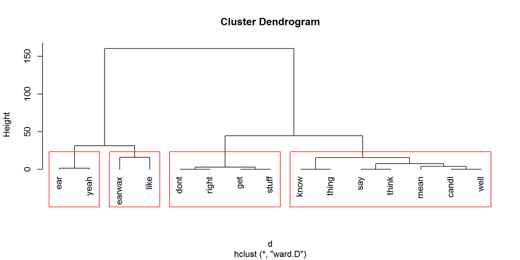

```r
#convert dtm to matrix
m <- as.matrix(subset(freq_df_Josh, freq > 10))

#compute distance between document vectors
d <- dist(m)

#hierarchical clustering with Ward’s method
groups <- hclust(d ,method = "ward.D")

#plot dendogram
plot(groups, hang = -1)
rect.hclust(groups, 4)
```

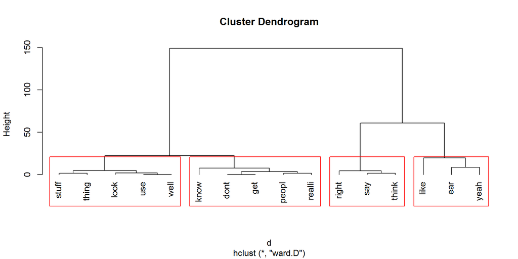

```r
#convert dtm to matrix
m <- as.matrix(subset(freq_df_Chuck, freq > 10))

#compute distance between document vectors
d <- dist(m)

#hierarchical clustering with Ward’s method
groups <- hclust(d ,method = "ward.D")

#plot dendogram
plot(groups, hang = -1)
rect.hclust(groups, 4)
```

## Sentiment analysis

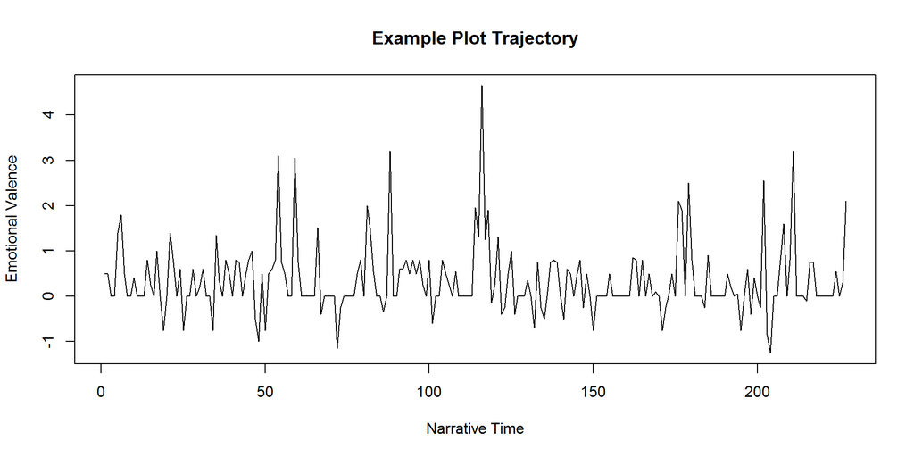

```r
library(syuzhet)

plot(
  get_sentiment(lines_Josh, method="syuzhet"),
  type="l",
  main="Example Plot Trajectory",
  xlab = "Narrative Time",
  ylab= "Emotional Valence"
)
```

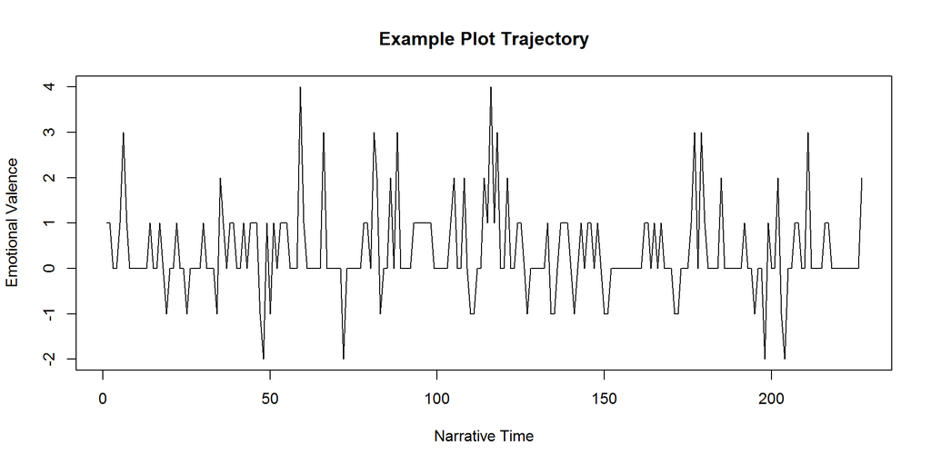

```r
plot(
  get_sentiment(lines_Josh, method="bing"),
  type="l",
  main="Example Plot Trajectory",
  xlab = "Narrative Time",
  ylab= "Emotional Valence"
)
```

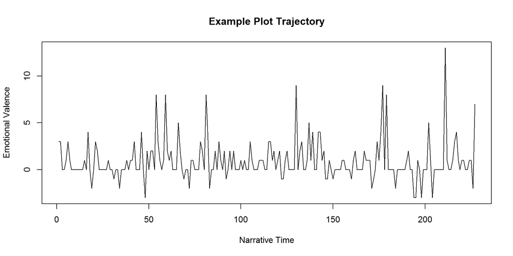

```r
plot(
  get_sentiment(lines_Josh, method="afinn"),
  type="l",
  main="Example Plot Trajectory",
  xlab = "Narrative Time",
  ylab= "Emotional Valence"
)
```

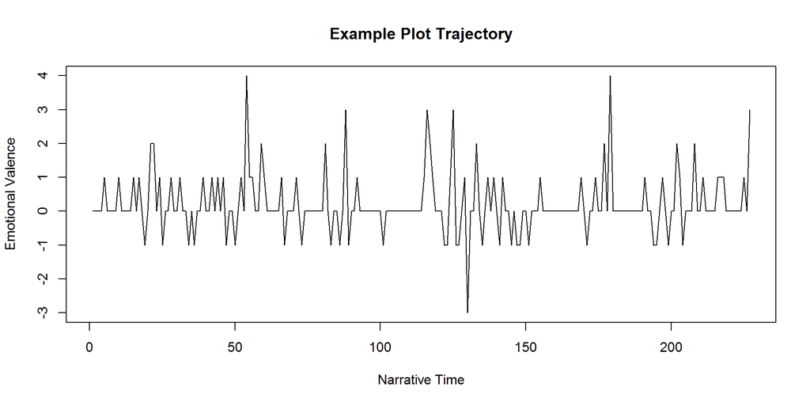

```r
plot(
  get_sentiment(lines_Josh, method="nrc"),
  type="l",
  main="Example Plot Trajectory",
  xlab = "Narrative Time",
  ylab= "Emotional Valence"
)
```

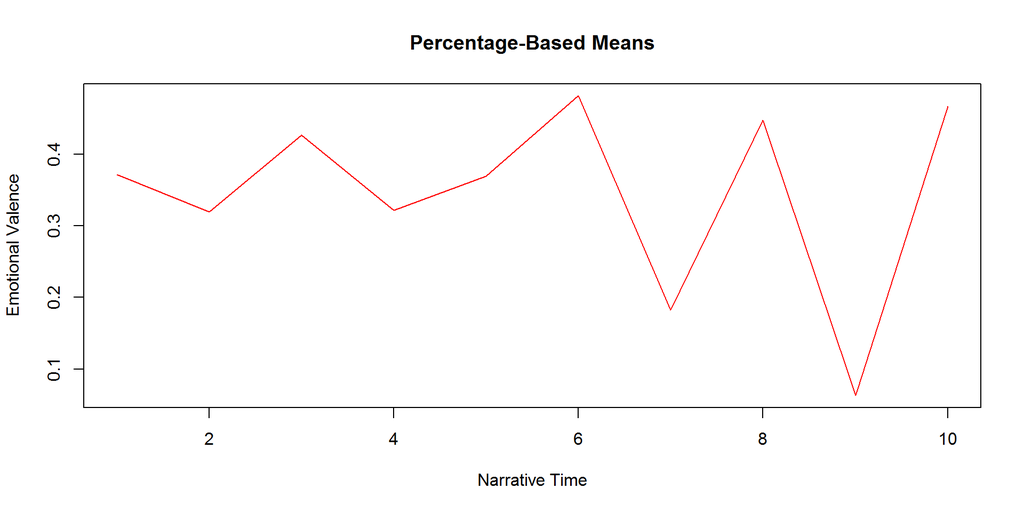

```r
s_v_sentiment <- get_sentiment(lines_Josh, method="syuzhet")

percent_vals <- get_percentage_values(s_v_sentiment, bins = 10)

plot(
  percent_vals,
  type="l",
  main="Percentage-Based Means",
  xlab = "Narrative Time",
  ylab= "Emotional Valence",
  col="red"
)
```

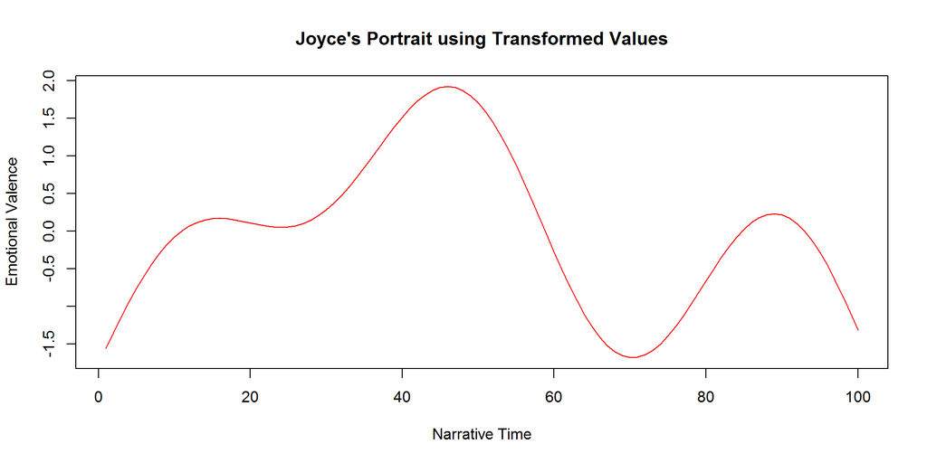

```r
ft_values <- get_transformed_values(
  s_v_sentiment,
  low_pass_size = 3,
  x_reverse_len = 100,
  padding_factor = 2,
  scale_vals = TRUE,
  scale_range = FALSE
)

plot(
  ft_values,
  type ="l",
  main ="Joyce's Portrait using Transformed Values",
  xlab = "Narrative Time",
  ylab = "Emotional Valence",
  col = "red"
)
```

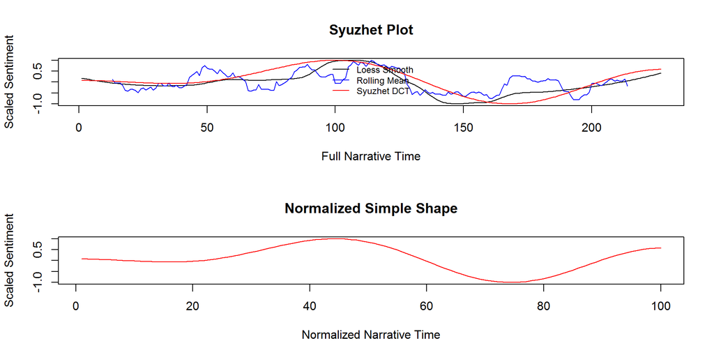

```r
simple_plot(s_v_sentiment)
```

```r
sentiment_Josh <- get_nrc_sentiment(lines_Josh)
length(lines_Josh)
```

```
## [1] 227
```

```r
dim(sentiment_Josh)
```

```
## [1] 227  10
```